# Predicting the Quality of Weight Lifting Exercises

mangei11

Thursday, January 28, 2016

## Summary

The goal of this study was to predict how well weight lifting activities are performed from from data from accelerometers on the belt, forearm, arm and dumbell. The data for traing and testing a prediction algorithm was provided by Wallace Ugulino, Eduardo Velloso, and Hugo Fuks, and is available at http://groupware.les.inf.puc-rio.br/har under *Weight Lifting Exercises (WLE) Dataset*. The training and test data sets for this study were downloaded from https://d396qusza40orc.cloudfront.net/predmachlearn/pml-training.csv and https://d396qusza40orc.cloudfront.net/predmachlearn/pml-testing.csv, respectively.

## Introduction

As described in more detail on http://groupware.les.inf.puc-rio.br/har, six young health participants were asked to perform one set of 10 repetitions of the Unilateral Dumbbell Biceps Curl in five different fashions: exactly according to the specification (Class A), throwing the elbows to the front (Class B), lifting the dumbbell only halfway (Class C), lowering the dumbbell only halfway (Class D) and throwing the hips to the front (Class E).

Class A corresponds to the specified execution of the exercise, while the other 4 classes correspond to common mistakes. Participants were supervised by an experienced weight lifter to make sure the execution complied to the manner they were supposed to simulate. The exercises were performed by six male participants aged between 20-28 years, with little weight lifting experience. A relatively light dumbbell (1.25kg) was used for safe and controlled simulation of the mistakes.

From the article by the researches who provided the data set, measurements used four 9 degree-of-freedom Razor inertial measurement units, which provide three-axes acceleration, gyroscope, and magnetometer data at a joined sampling rate of 45Hz. In addition to the raw data, statistical summaries (mean, variance, max, min, amplitude, kurtosis and skewness) are provided.

### R Packages and code settings

Algorithm development, data visualization and analysis are based on the following R packages:

```r
# settings
library(ggplot2)
library(caret)
library(knitr)
opts_chunk$set(echo = TRUE)

# Record date and time
procdate <- format(Sys.time(),"%a %b %d %X %Y" )

# Seed for random number generator
set.seed(74723)
```

The modeling and prediction results presented in this report were produced on Fri Jan 29 22:46:50 2016.

### Datasets

The training and test data were downloaded from the mentioned websites as as comma-separated-value files. Both files are stored in the subfolder “data” of the working directory.

```r
path <- "./data"
#training data
trainfile <- "pml-training.csv"
training <- read.csv(paste(path, trainfile, sep="/"))
#testing data
testfile <- "pml-testing.csv"
testing <- read.csv(paste(path, testfile, sep="/"))
```

For proper estimation of prediction errors, the training data set is split into building and validation sets.

```r
inbuild <- createDataPartition(y=training$classe, p=0.7, list=FALSE)
build <- training[inbuild,]
validate <- training[-inbuild,]
```

## Exploratory Data Analysis

For the development of a suitable model strategy, the training data set is analysed with respect to its structure, and the characteristics of the information available. With the goal of predicting the quality class on data simultaneously acquired at an instant in time, only raw data and values calculated from instantaneous measurements are meaningful data. The observations in the data set are treated as independent samples.

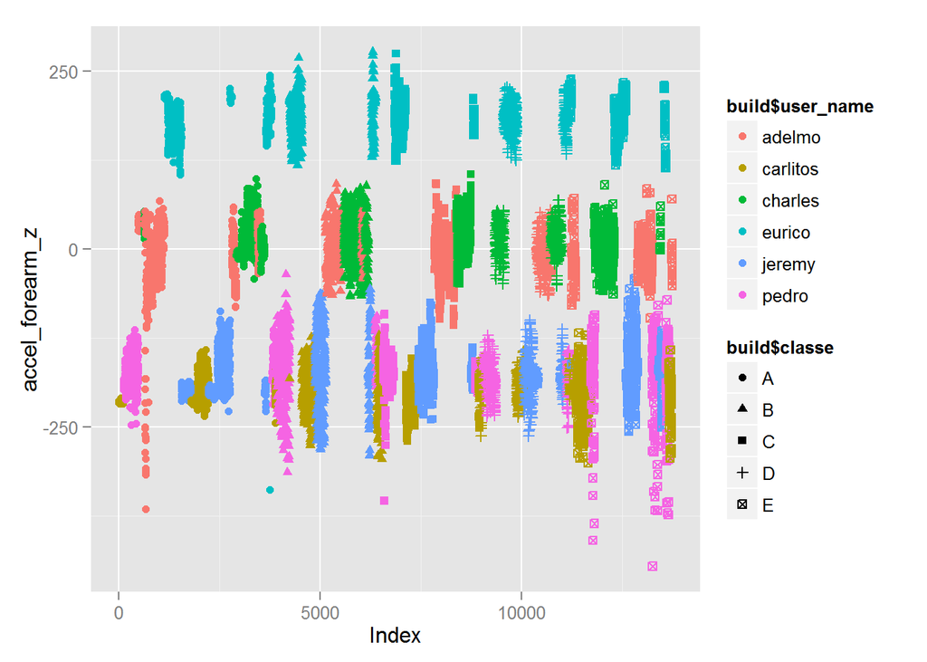

For the development of a robust prediction algorithm, outliers defined as observations for which at least one value of a raw data variable was outside chosen limits. These limits were defined for each variable through the respective median value and 1% and 99% quantiles.

```r
# names of raw data columns
varnames_raw <- names(build)[c(37:45,60:67,113:121,151:159)]
test <- sapply(subset(build,select=varnames_raw), function(x){
        qdat <- quantile(x, probs=c(0.01,0.5,0.99))
        x < (qdat[1]-(qdat[2]-qdat[1])) | (x >qdat[3]+(qdat[3]-qdat[2]))
})
outlier <- as.logical(rowSums(test))
noutlier <- sum(outlier)
build <- build[outlier==FALSE,]
```

## Model development

A set of variables characteristic for each sensor location (belt, arm, dumbbell, and forearm) was chosen upon analysis of index and pair plots. In order to avoid overfitting of the data and to reduce computation times for training the model, the number of variables was kept small.

### Model 1

```r
fitnames <- names(build)[c(8,9,63,64,65,84,120,156,160)]
fitnames
```

```
## [1] "roll_belt"         "pitch_belt"        "accel_arm_x"
## [4] "accel_arm_y"       "accel_arm_z"       "roll_dumbbell"
## [7] "magnet_dumbbell_y" "accel_forearm_z"   "classe"
```

The data set for training is complete as all variables are quantified for all observations.

```r
missing <- sum(is.na(subset(build, select=fitnames)))
missing
```

```
## [1] 0
```

```r
build1 <- subset(build, select=fitnames)
cont<-trainControl(method="cv", number=5)
rfmod <- train(classe~., data=build1, method="rf", trControl=cont)
rfmod
```

```
## Random Forest
##
## 13609 samples
##     8 predictor
##     5 classes: 'A', 'B', 'C', 'D', 'E'
##
## No pre-processing
## Resampling: Cross-Validated (5 fold)
## Summary of sample sizes: 10886, 10887, 10887, 10888, 10888
## Resampling results across tuning parameters:
##
##   mtry  Accuracy   Kappa      Accuracy SD  Kappa SD
##   2     0.9600996  0.9495035  0.004727409  0.005988369
##   5     0.9543678  0.9422507  0.007844750  0.009934215
##   8     0.9455495  0.9310867  0.008554200  0.010808256
##
## Accuracy was used to select the optimal model using  the largest value.
## The final value used for the model was mtry = 2.
```

```r
rfmod$finalModel
```

```
##
## Call:
##  randomForest(x = x, y = y, mtry = param$mtry)
##                Type of random forest: classification
##                      Number of trees: 500
## No. of variables tried at each split: 2
##
##         OOB estimate of  error rate: 3.43%
## Confusion matrix:
##      A    B    C    D    E class.error
## A 3812   16   12   36   11  0.01929509
## B   56 2509   52   26    5  0.05249245
## C   22   32 2321   18    2  0.03089770
## D   38    6   74 2120    2  0.05357143
## E    6   15   25   13 2380  0.02419024
```

```r
varImp(rfmod)
```

```
## rf variable importance
##
##                    Overall
## roll_belt         100.0000
## pitch_belt         54.1143
## magnet_dumbbell_y  48.4260
## roll_dumbbell      23.2961
## accel_arm_x        18.4151
## accel_forearm_z    10.5286
## accel_arm_y         0.9477
## accel_arm_z         0.0000
```

It appears the variables “accel_arm_y” and “accel_arm_z” have little importantance and can thus be removed from the predictor list. To get a more realistic estimate of the out-of-sample error rate, predictions for the validation set are used.

```r
validate1 <- subset(validate, select=fitnames)
predval1 <- predict(rfmod, newdata=validate1)
confusionMatrix(predval1,validate1$classe)
```

```
## Confusion Matrix and Statistics
##
##           Reference
## Prediction    A    B    C    D    E
##          A 1646   19    1   19    2
##          B    7 1091   14    1   20
##          C    4   13  999   23   13
##          D   12   14   12  920   15
##          E    5    2    0    1 1032
##
## Overall Statistics
##
##                Accuracy : 0.9665
##                  95% CI : (0.9616, 0.971)
##     No Information Rate : 0.2845
##     P-Value [Acc > NIR] : < 2.2e-16
##
##                   Kappa : 0.9577
##  Mcnemar's Test P-Value : 4.156e-10
##
## Statistics by Class:
##
##                      Class: A Class: B Class: C Class: D Class: E
## Sensitivity            0.9833   0.9579   0.9737   0.9544   0.9538
## Specificity            0.9903   0.9912   0.9891   0.9892   0.9983
## Pos Pred Value         0.9757   0.9629   0.9496   0.9455   0.9923
## Neg Pred Value         0.9933   0.9899   0.9944   0.9910   0.9897
## Prevalence             0.2845   0.1935   0.1743   0.1638   0.1839
## Detection Rate         0.2797   0.1854   0.1698   0.1563   0.1754
## Detection Prevalence   0.2867   0.1925   0.1788   0.1653   0.1767
## Balanced Accuracy      0.9868   0.9745   0.9814   0.9718   0.9761
```

The expected accuracy is over 90%, which, given the small number of predictors, is a reasonably good value.

### Final Model

Other models could be built by increasing the number of predictors to improve the quality of the fit. Based on the estimated out-of-sample error from testing the model with the validation data, a final model would be selected. For lack of time and acceptable accuracy, Model 1 is chosen for the final data set

## Final prediction on the testing data

```r
test <- subset(testing, select=fitnames[1:(length(fitnames)-1)])
predtest <- predict(rfmod, newdata=test)
res <- data.frame(problem_id=testing$problem_id,classe=predtest)
res
```

```
##    problem_id classe
## 1           1      B
## 2           2      A
## 3           3      B
## 4           4      A
## 5           5      A
## 6           6      E
## 7           7      D
## 8           8      B
## 9           9      A
## 10         10      A
## 11         11      B
## 12         12      C
## 13         13      B
## 14         14      A
## 15         15      E
## 16         16      E
## 17         17      A
## 18         18      B
## 19         19      B
## 20         20      B
```